# Regresión Lineal

## 1. Introducción

Son frecuentes en la práctica situaciones en las que se cuenta con observaciones de diversas variables, y es razonable pensar en una relación entre estas. El poder determinar si existe esta relación, es de interés. Por una parte, esto permitiría, conocidos los valores de algunas variables, efectuar predicciones sobre los valores previsibles de otra. Podríamos también responder con criterio estadístico a cuestiones acerca de la relación de una variable sobre otra. El análisis de regresión es una método estadístico para investigar y modelar la relación lineal existente entre variables. Son numerosas las aplicaciones de la regresión en cualquier área. Por ejemplo, se podría intentar explicar el peso en función de la altura.

El objetivo de un modelo de regresión es tratar de explicar la relación que existe entre una variable dependiente (variable respuesta) $Y$, y un conjunto de variables independientes (variables explicativas) $X_1$,..., $X_m$. Este modelo puede ser expresado como:

$${\displaystyle Y=\beta _{0}+\beta _{1}X_{1}+\cdots +\beta _{m}X_{m}+\varepsilon_i }$$

donde:

${\displaystyle Y}$: es la variable dependiente o variable de respuesta.\ ${\displaystyle X_{1},X_{2},\dots ,X_{m}}$: son las variables explicativas, independientes o regresoras.\ ${\displaystyle \beta _{0},\beta _{1},\beta _{2},\dots ,\beta _{m}}$: son los parámetros del modelo, miden la influencia que las variables explicativas tienen sobre la variable respuesta.\ ${\displaystyle \beta _{0}}$: es la intersección o término "constante".\ ${\displaystyle m}$ es el número de parámetros independientes a tener en cuenta en la regresión.\ $\varepsilon_i$: es el error.

Un modelo de regresión no implica que haya una relación de causa efecto entre las variables. Aunque pueda existir una marcada relación empírica entre dos o más variables, no puede considerarse como prueba de que las variables regresoras y la respuesta estén relacionadas en forma de causa-efecto.

## 2. Breve Historia

La primera forma de regresión lineal documentada fue el método de los mínimos cuadrados que fue publicada por Legendre en 1805, Gauss publicó un trabajo en donde desarrollaba de manera más profunda el método de los mínimos cuadrados, y en dónde se incluía una versión del teorema de Gauss-Márkov.\ El término regresión fue introducido por Francis Galton en su libro Natural inheritance (1889) y fue confirmada por Karl Pearson. Su trabajo se centró en la descripción de los rasgos físicos de los descendientes (variable A) a partir de los de sus padres (variable B).

[figure not shown]

Estudiando la altura de padres e hijos a partir de más de mil registros de grupos familiares, se llegó a la conclusión de que los padres muy altos tenían una tendencia a tener hijos que heredaban parte de esta altura, pero que revelaban también una tendencia a regresar a la media. Galton generalizó esta tendencia bajo la "ley de la regresión universal": Cada peculiaridad en un hombre es compartida por sus descendientes, pero en media, en un grado menor.

[figure not shown]

La primera forma de regresiones lineales documentada fue el método de los mínimos cuadrados, el cual fue publicado por Legendre en 1805,1 y en dónde se incluía una versión del teorema de Gauss-Márkov. Hoy en día el sentido de regresión es el de predicción de una medida basándonos en el conocimiento de otra.

## 3. Planteamiento del algoritmo

### 3.1 Regresión lineal simple

El modelo de regresión lineal simple, es un modelo con un solo regresor $x$ que tiene relación con una variable respuesta $y$, donde la relación es una línea recta. El modelo se puede expresar de la siguiente forma:

$$y=\beta_0 + \beta_1 x + \varepsilon$$

donde la ordenada al origen $\beta_0$ y la pendiente $\beta_1$ son constantes desconocidas, y $\varepsilon$ es un componente aleatorio de error. Se supone que los errores tienen promedio $0$ y varianza $\sigma^2$ desconocida. Además, se suele suponer que los errores no están correlacionados.

Dado que $\beta_0$ y $\beta_1$ son desconocidos, a partir de una muestra de datos, esos datos pueden obtenerse en un experimento controlado, diseñado en forma específica para recolectarlos, o en un estudio observacional, o a partir de registros históricos existentes se obtienen sus estimaciones $\hat{\beta}_0$ y $\hat{\beta}_1$. Estas estimaciones se conocen como coeficientes de regresión ó estimaciones por minimos cuadrados, ya que toman aquellos valores que minimizan la suma de cuadrados residuales, dando lugar a la recta que pasa más cerca de todos los puntos.

#### 3.1.1 Estmación de $\beta_0$ y $\beta_1$

Para la estimación de $\beta_0$ y $\beta_1$ se utilizará el **Método de mínimos cuadrados**, es decir, se estiman $\beta_0$ y $\beta_1$ tal que la suma de los cuadrados de las diferencias entre las observaciones $y_i$ y la línea recta sea mínima, lo que quiere decir, dado:

$$y_i=\beta_0 + \beta_1 x_i +\varepsilon_i$$

Se quiere minimizar:

$$S(\beta_0,\beta_1)=\sum_{i=1}^{n}(y_i-\beta_0-\beta_1 x_i)^2$$

De esta manera, los estimadores de $\beta_0$ y $\beta_1$, deben satisfacer, las siguientes ecuaciones llamadas **ecuaciones normales de mínimos cuadrados**:

$$\frac{\partial S}{\partial \beta_0} \Big | _{\hat{\beta_0} ,\hat{\beta_1}}=-2\sum_{i=1}^{n} (y_i-\hat{\beta}_0-\hat{\beta}_1 x_i)=0$$

$$\frac{\partial S}{\partial \beta_1} \Big | _{\hat{\beta_0} ,\hat{\beta_1}}=-2\sum_{i=1}^{n} (y_i-\hat{\beta}_0-\hat{\beta}_1 x_i)x_i=0$$

De las cuales se obtiene:

$$\hat{\beta}_0 = \bar{y} - \hat{\beta}_1 \bar{x} $$

$$\hat{\beta}_1=\frac{\sum_{i=1}^{n} y_i x_i -\frac{\big(\sum_{i=1}^{n} y_i\big)\big(\sum_{i=1}^{n} x_i \big)}{n}}{\sum_{i=1}^{n} x_i^2 -\frac{\big(\sum_{i=1}^{n} x_i \big)^2}{n}}=\frac{S_{xy}}{S_x^2}$$

Además la diferencia entre el valor observado $y_i$ y el valor ajustado $\hat{y}_i$ es llamado residual:

$$e_i =y_i-\hat{y}_i = y_i -(\hat{\beta}_0-\hat{\beta}_1x_i),\ i=1,2,...,n$$

Los residuales son utiles para observar el ajuste del modelo de regresión ajustado a los datos. Finalmente el modelo ajustado de regresión lineal simple es

$${\displaystyle {\hat {y}}={\hat {\beta }}_{0}+{\hat {\beta }}_{1}x}$$

### 3.2 Regresión lineal multiple

Constantemente en la práctica de la investigación estadística, se encuentran variables que de alguna manera están relacionadas entre sí, por lo que es posible que una de las variables puedan relacionarse matemáticamente en función de otra u otras variables. La regresión lineal permite analizar la relación entre dos o más variables a través de ecuaciones, lo que se denomina regresión lineal múltiple.

Este modelo cuenta con varias variables regresoras, por lo que cuenta con varios parámetros, para la regresión lineal múltiple, se asume que la variable de respuesta ${\displaystyle Y}$ se relaciona con las variables regresoras ${X_{1},\dots ,X_{m}}$ mediante la relación funcional:

$${\displaystyle {\begin{aligned}Y&=\beta _{0}+\beta _{1}X_{1}+\beta _{2}X_{2}+\cdots +\beta _{m}X_{m}+\varepsilon \\&=\beta _{0}+\sum _{j=1}^{m}\beta _{j}X_{j}+\varepsilon \end{aligned}}}$$

Supongamos que se tiene una muestra de tamaño ${\displaystyle n}$ dada por ${\displaystyle \{(x_{ij},y_{i})\}}$ con ${\displaystyle j=1,2,\dots ,m}$ donde ${\displaystyle x_{ij}}$ denota el ${\displaystyle i}$ i-ésimo valor observado en el regresor ${\displaystyle X_{j}}$ y ${\displaystyle y_{i}}$ denota la ${\displaystyle i}$ i-ésima observación de ${\displaystyle Y}$ entonces el modelo toma la forma

${\displaystyle {\begin{aligned}y_{i}&=\beta _{0}+\sum _{j=1}^{m}\beta _{j}x_{ij}+\varepsilon _{i}\&=\beta _{0}+\beta _{1}x_{i1}+\beta _{2}x_{i2}+\cdots +\beta _{m}x_{im}+\varepsilon _{i}\end{aligned}}}$, donde ${\displaystyle \varepsilon _{i}}$ es el error asociado a la i-ésima medición del valor ${\displaystyle X_{j}}$ y sigue los supuestos usuales de modo que ${\displaystyle \varepsilon _{i}\sim N(0,\sigma ^{2})}$ (media cero, varianza constante e igual a $\sigma^2$ y ${\displaystyle \operatorname {Cov} (\varepsilon _{i},\varepsilon _{j})=0}$ con ${\displaystyle i\neq j}$.

De manera similar se obtiene:

$${\displaystyle {\hat {\beta }}=(X^{T}X)^{-1}X^{T}Y}$$

## 4. Ejemplo de regresión lineal

Ahora se utilizará un conjunto de datos para aplicar el método de regresión lineal. Este conjunto de datos es un registro de 1338 personas, las cuales indicaron información y el valor que pagan por seguridad en salud. La base tiene las siguientes variables:

- **Edad**: edad del beneficiario principal
- **Genero**: Genero contratista del seguro (mujer, hombre)
- **Indice**: índice de masa corporal, pesos que son relativamente altos o bajos en relación con la altura, índice objetivo de peso corporal (kg / m ^ 2) utilizando la relación entre la altura y el peso, idealmente 18,5 a 24,9
- **Hijos**: Número de hijos cubiertos por el seguro médico / Número de dependientes
- **Fumador**: Si la persona es fuma o no.
- **Región**: el área residencial del beneficiario en los EE. UU., noreste, sureste, suroeste, noroeste.
- **Costo**: Total costos médicos individuales facturados por el seguro médico.

## Importar Librerias

```python
from sklearn import linear_model
from sklearn.metrics import mean_squared_error
from sklearn.linear_model import LinearRegression
from sklearn.model_selection import train_test_split
from sklearn.preprocessing import LabelEncoder
from sklearn import metrics
import numpy as np
import scipy as sc
import matplotlib.pyplot as plt
import pandas as pd
import seaborn as sns
from scipy import stats
import os
```

```python
os.getcwd()
```

```
'C:\\Users\\Nexbas\\Documents\\Diplomado\\Tareas'
```

## Cargar Base de datos

Primero, observamos la base, cuantos datos tiene, variables y una observación de estadística de resumen.

```python
data=pd.read_csv(f"{os.getcwd()}\Regresion\insurance.csv")
```

```python
data.columns=['Edad','Genero','Indice','Hijos','Fumador','Region','Costo']
```

```python
data.count()
```

```
Edad       1338
Genero     1338
Indice     1338
Hijos      1338
Fumador    1338
Region     1338
Costo      1338
dtype: int64
```

```python
data.dtypes
```

```
Edad         int64
Genero      object
Indice     float64
Hijos        int64
Fumador     object
Region      object
Costo      float64
dtype: object
```

```python
data.head()
```

|  | Edad | Genero | Indice | Hijos | Fumador | Region | Costo |
| --- | --- | --- | --- | --- | --- | --- | --- |
| 0 | 19 | female | 27.900 | 0 | si | Souroeste | 16884.92400 |
| 1 | 18 | male | 33.770 | 1 | no | Sureste | 1725.55230 |
| 2 | 28 | male | 33.000 | 3 | no | Sureste | 4449.46200 |
| 3 | 33 | male | 22.705 | 0 | no | Noroeste | 21984.47061 |
| 4 | 32 | male | 28.880 | 0 | no | Noroeste | 3866.85520 |

## Análisis Exploratorio

```python
data.describe()
```

|  | Edad | Indice | Hijos | Costo |
| --- | --- | --- | --- | --- |
| count | 1338.000000 | 1338.000000 | 1338.000000 | 1338.000000 |
| mean | 39.207025 | 30.663397 | 1.094918 | 13270.422265 |
| std | 14.049960 | 6.098187 | 1.205493 | 12110.011237 |
| min | 18.000000 | 15.960000 | 0.000000 | 1121.873900 |
| 25% | 27.000000 | 26.296250 | 0.000000 | 4740.287150 |
| 50% | 39.000000 | 30.400000 | 1.000000 | 9382.033000 |
| 75% | 51.000000 | 34.693750 | 2.000000 | 16639.912515 |
| max | 64.000000 | 53.130000 | 5.000000 | 63770.428010 |

#### Revisar datos duplicados

```python
data[data.duplicated()]
```

|  | Edad | Genero | Indice | Hijos | Fumador | Region | Costo |
| --- | --- | --- | --- | --- | --- | --- | --- |
| 581 | 19 | male | 30.59 | 0 | no | Noroeste | 1639.5631 |

#### Retirar datos duplicados

```python
data = data.drop(581)
```

```python
data.count()
```

```
Edad       1337
Genero     1337
Indice     1337
Hijos      1337
Fumador    1337
Region     1337
Costo      1337
dtype: int64
```

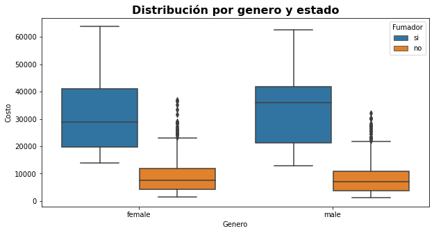

```python
fig, ax = plt.subplots()
fig.set_size_inches(10, 5)
sns.boxplot(x='Genero', y='Costo',hue="Fumador", data=data)
ax.set_title('Distribución por genero y estado',fontsize=16, weight="bold")
```

En el anterior gráfico se observa:

- 1. Los costos son independientes del Genero de la persona.
- 1. El ser fumador hace que los costos del seguro sean más altos.
- 1. Existen personas no fumadoras que tienen costos altos en comparación con las demás personas del mismo grupo.

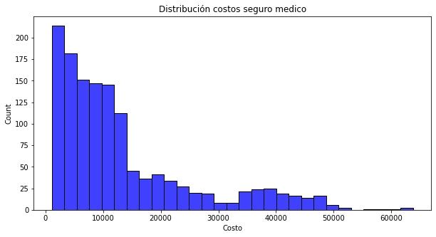

```python
fig, ax = plt.subplots()
fig.set_size_inches(10, 5)
sns.histplot(data.Costo, ax=ax, color="Blue")
ax.set_title("Distribución costos seguro medico")
```

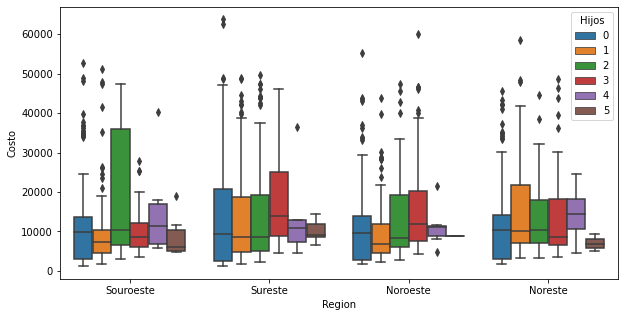

```python
fig, ax = plt.subplots()
fig.set_size_inches(10, 5)
sns.boxplot(x="Region", y="Costo", hue="Hijos", data=data, ax=ax)
```

Del anterior gráfico se puede concluir que no existe una diferencia significativa a simple viste entre las regiones, aunque hay unas regiones en las cuales el costo tiene una distribución más dispersa por ejemplo en la sureste. Además en la región suroeste hay una personas con dos hijos que tienen costos altos en salud.

#### Creación de dummies para variables categóricas

```python
data['Costo']=np.log(data['Costo'])
```

```python
data=pd.get_dummies(data,drop_first=True)
data
```

|  | Edad | Indice | Hijos | Costo | Genero_male | Fumador_si | Region_Noroeste | Region_Souroeste | Region_Sureste |
| --- | --- | --- | --- | --- | --- | --- | --- | --- | --- |
| 0 | 19 | 27.900 | 0 | 9.734176 | 0 | 1 | 0 | 1 | 0 |
| 1 | 18 | 33.770 | 1 | 7.453302 | 1 | 0 | 0 | 0 | 1 |
| 2 | 28 | 33.000 | 3 | 8.400538 | 1 | 0 | 0 | 0 | 1 |
| 3 | 33 | 22.705 | 0 | 9.998092 | 1 | 0 | 1 | 0 | 0 |
| 4 | 32 | 28.880 | 0 | 8.260197 | 1 | 0 | 1 | 0 | 0 |
| ... | ... | ... | ... | ... | ... | ... | ... | ... | ... |
| 1333 | 50 | 30.970 | 3 | 9.268661 | 1 | 0 | 1 | 0 | 0 |
| 1334 | 18 | 31.920 | 0 | 7.698927 | 0 | 0 | 0 | 0 | 0 |
| 1335 | 18 | 36.850 | 0 | 7.396233 | 0 | 0 | 0 | 0 | 1 |
| 1336 | 21 | 25.800 | 0 | 7.604867 | 0 | 0 | 0 | 1 | 0 |
| 1337 | 61 | 29.070 | 0 | 10.279914 | 0 | 1 | 1 | 0 | 0 |

1337 rows × 9 columns

### Correlación

```python
data.corr()
```

|  | Edad | Indice | Hijos | Costo | Genero_male | Fumador_si | Region_Noroeste | Region_Souroeste | Region_Sureste |
| --- | --- | --- | --- | --- | --- | --- | --- | --- | --- |
| Edad | 1.000000 | 0.109344 | 0.041536 | 0.526927 | -0.019814 | -0.025587 | 0.001495 | 0.009415 | -0.012311 |
| Indice | 0.109344 | 1.000000 | 0.012755 | 0.132822 | 0.046397 | 0.003746 | -0.136138 | -0.006211 | 0.270057 |
| Hijos | 0.041536 | 0.012755 | 1.000000 | 0.160336 | 0.017848 | 0.007331 | 0.026044 | 0.021538 | -0.023492 |
| Costo | 0.526927 | 0.132822 | 0.160336 | 1.000000 | 0.007009 | 0.665718 | -0.015425 | -0.042473 | 0.014968 |
| Genero_male | -0.019814 | 0.046397 | 0.017848 | 0.007009 | 1.000000 | 0.076596 | -0.012482 | -0.003767 | 0.017578 |
| Fumador_si | -0.025587 | 0.003746 | 0.007331 | 0.665718 | 0.076596 | 1.000000 | -0.036321 | -0.037168 | 0.068282 |
| Region_Noroeste | 0.001495 | -0.136138 | 0.026044 | -0.015425 | -0.012482 | -0.036321 | 1.000000 | -0.320493 | -0.345909 |
| Region_Souroeste | 0.009415 | -0.006211 | 0.021538 | -0.042473 | -0.003767 | -0.037168 | -0.320493 | 1.000000 | -0.346614 |
| Region_Sureste | -0.012311 | 0.270057 | -0.023492 | 0.014968 | 0.017578 | 0.068282 | -0.345909 | -0.346614 | 1.000000 |

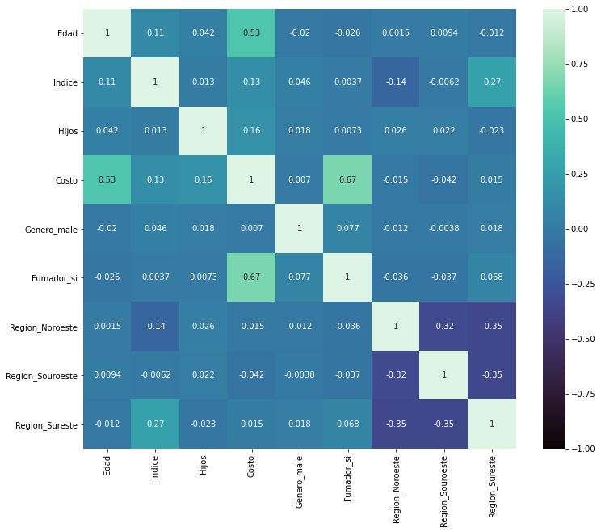

```python
corr = data.corr()

plt.figure(figsize=(12, 10))
sns.heatmap(corr, annot=True, vmin=-1.0, cmap='mako')
plt.show()
```

No se observan correlaciones significativamente altas, por lo tengo procedemos a jsutar el modelo.

### División muestra de entrenamiento y test

```python
Y= data[['Costo']]
X= data.drop(['Costo'],axis=1)
```

```python
X_train, X_test, y_train, y_test = train_test_split(X, Y, test_size=0.20)
```

#### Ajuste de modelo

```python
from sklearn.linear_model import LinearRegression
lr=LinearRegression()
lr.fit(X_train,y_train)

print(lr.score(X_train,y_train))
print(lr.score(X_test,y_test))
```

```
0.7729267281978047
0.7440482112286732
```

## Conclusiones

- La regresión lineal simple y la regresión múltiple, analiza la relación de dos o mas variables.
- El objetivo de ajustar un modelo de regresión lineal es estimar los valores de una variable respuesta con base en una o más variables explicativas.
- Al ajustar un modelo de regresión simple o múltiple a una nube de puntos es importante disponer de alguna medida que permita medir la bondad del ajuste.(\R^2)
- Es necesario también tener en cuenta los supuestos del modelo de regresión y validarlos. Para que aplicar el modelo tenga sentido.